# Grupo 14_Trabajo_Final_Asignatura 3

Integrantes: Mercedes de la Torre Fuentes/Diego Alonso Solano Bolaños/Kattia Zúñiga Acosta / Ricardo Mir de Francia/Jaco Warris

2024-12-20

## **1.Analisis Exploratorio del Conjunto Datos**

### **Introducción**

```r
library(readr)
obesity_data_raw = read.csv("./data/ObesityDataSet_raw_and_data_sinthetic.csv", header = T, sep = ",")
head(obesity_data_raw)
```

```
##   Gender Age Height Weight family_history_with_overweight FAVC FCVC NCP
## 1 Female  21   1.62   64.0                            yes   no    2   3
## 2 Female  21   1.52   56.0                            yes   no    3   3
## 3   Male  23   1.80   77.0                            yes   no    2   3
## 4   Male  27   1.80   87.0                             no   no    3   3
## 5   Male  22   1.78   89.8                             no   no    2   1
## 6   Male  29   1.62   53.0                             no  yes    2   3
##        CAEC SMOKE CH2O SCC FAF TUE       CALC                MTRANS
## 1 Sometimes    no    2  no   0   1         no Public_Transportation
## 2 Sometimes   yes    3 yes   3   0  Sometimes Public_Transportation
## 3 Sometimes    no    2  no   2   1 Frequently Public_Transportation
## 4 Sometimes    no    2  no   2   0 Frequently               Walking
## 5 Sometimes    no    2  no   0   0  Sometimes Public_Transportation
## 6 Sometimes    no    2  no   0   0  Sometimes            Automobile
##            NObeyesdad
## 1       Normal_Weight
## 2       Normal_Weight
## 3       Normal_Weight
## 4  Overweight_Level_I
## 5 Overweight_Level_II
## 6       Normal_Weight
```

```r
tail(obesity_data_raw)
```

```
##      Gender      Age   Height   Weight family_history_with_overweight FAVC FCVC
## 2106 Female 21.28597 1.726920 131.3358                            yes  yes    3
## 2107 Female 20.97684 1.710730 131.4085                            yes  yes    3
## 2108 Female 21.98294 1.748584 133.7429                            yes  yes    3
## 2109 Female 22.52404 1.752206 133.6894                            yes  yes    3
## 2110 Female 24.36194 1.739450 133.3466                            yes  yes    3
## 2111 Female 23.66471 1.738836 133.4726                            yes  yes    3
##      NCP      CAEC SMOKE     CH2O SCC      FAF      TUE      CALC
## 2106   3 Sometimes    no 1.796267  no 1.728332 0.897924 Sometimes
## 2107   3 Sometimes    no 1.728139  no 1.676269 0.906247 Sometimes
## 2108   3 Sometimes    no 2.005130  no 1.341390 0.599270 Sometimes
## 2109   3 Sometimes    no 2.054193  no 1.414209 0.646288 Sometimes
## 2110   3 Sometimes    no 2.852339  no 1.139107 0.586035 Sometimes
## 2111   3 Sometimes    no 2.863513  no 1.026452 0.714137 Sometimes
##                     MTRANS       NObeyesdad
## 2106 Public_Transportation Obesity_Type_III
## 2107 Public_Transportation Obesity_Type_III
## 2108 Public_Transportation Obesity_Type_III
## 2109 Public_Transportation Obesity_Type_III
## 2110 Public_Transportation Obesity_Type_III
## 2111 Public_Transportation Obesity_Type_III
```

```r
colSums(is.na(obesity_data_raw))
```

```
##                         Gender                            Age
##                              0                              0
##                         Height                         Weight
##                              0                              0
## family_history_with_overweight                           FAVC
##                              0                              0
##                           FCVC                            NCP
##                              0                              0
##                           CAEC                          SMOKE
##                              0                              0
##                           CH2O                            SCC
##                              0                              0
##                            FAF                            TUE
##                              0                              0
##                           CALC                         MTRANS
##                              0                              0
##                     NObeyesdad
##                              0
```

El objetivo de esta sección es explorar los datos disponibles en el conjunto de datos. A continuación, se realizarán las transformaciones necesarias para poder seguir trabajando con los datos más adelante.

Para facilitar este segundo objetivo, ya hemos creado un segundo marco de datos “obesity_data_preprocessed”: la idea es transformar el conjunto de datos inicial (denominado «obesity_data_raw») en este conjunto de datos preprocesado.

```r
  obesity_data_preprocessed = obesity_data_raw
```

#### **1.1 Gender**

Es una variable binaria que indica el género del/de la encuestado/-a.

```r
library(plotrix)
table(as.factor(obesity_data_raw$Gender))
```

```
##
## Female   Male
##   1043   1068
```

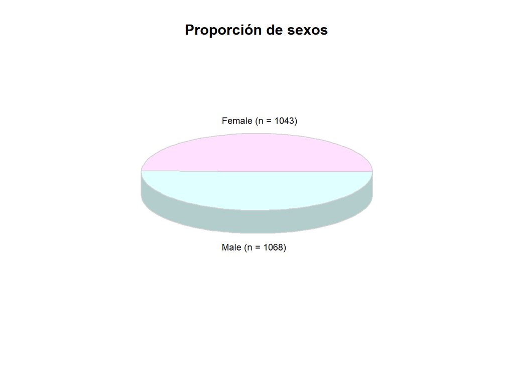

```r
pie3D(table(as.factor(obesity_data_raw$Gender)), main = "Proporción de sexos", col = c("thistle 1", "light cyan"), border = "lightgrey", labels = c("Female (n = 1043)", "Male (n = 1068)"), labelcex = 0.75)
```

Toma el valor ‘female’ o ‘male’, que, obviamente son valores válidos. No hay nigún valor estraño o faltante.

Además, constatamos que el conjunto de datos contiene una proporción entre hombres y mujeres encuestados bastante equitativa - es decir, hay 25 hombres más que mujeres, lo que supone una diferencia de (25 / 1043) * 100 ≈ 2.4%.

Dicha equivalencia es especialmente importante cuando se trata de cuestiones médicas - como son el sobrepeso y el obesitas - considerando que el funcionamiento del cuerpo de una persona estùa en gran medida relacionado con su sexo.

#### **Transformaciones**

Para poder trabajar mejor con esta variable, aplicamos *label encoding*, dejando dos valores numéricos al final:

- 0 - Female
- 1 - Male

```r
  obesity_data_preprocessed$Gender = as.integer(ifelse(obesity_data_preprocessed$Gender == 'Female', 0, 1))
```

#### **1.2 Age**

Se trata de una variable discreta ordinal que indica la edad de/ de la encuestado, en años.

Observamos que unos pocos valores distinctos de age son números enteros que tienen una frecuencia altas, mientras muchos valores distinctos son decimales con una frequencia baja. Probablemente, eso es resultado del hecho que parte de los datos son sintetizados, y no provienen de una encuesta. Es decir: son calculados por un algortimo.

Otra observación importante es que el conjunto de datos no está nada diversificada por edades - posiblemente debido al medio en el que se publicó esta encuesta (en linea). Un 82 porciento tiene menos que 30 años; un 97 porciento tiene menos que 40. El encuestado con mayor edad tiene 61 años.

Esto significa que, basándose en este conjunto de datos, probablemente no sea posible hacer afirmaciones sobre toda la población - como mucho sobre aquella parte cuya edad está fuertemente representada en nuestra muestra.

```r
print(round(cumsum(prop.table(table(round(obesity_data_raw$Age)))*100)))
```

```
##  14  15  16  17  18  19  20  21  22  23  24  25  26  27  28  29  30  31  32  33
##   0   0   1   4  14  22  29  41  48  59  63  67  77  79  80  82  84  87  88  90
##  34  35  36  37  38  39  40  41  42  43  44  45  46  47  48  51  52  55  56  61
##  92  92  93  94  95  97  98  98  99  99  99  99  99  99 100 100 100 100 100 100
```

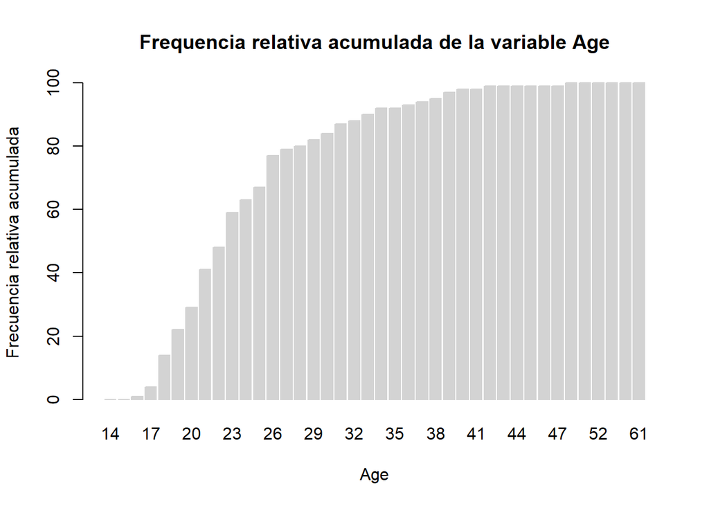

```r
barplot(round(cumsum(prop.table(table(round(obesity_data_raw$Age)))*100)), col = "light grey", border = "light grey", main = "Frequencia relativa acumulada de la variable Age", xlab = "Age", ylab ="Frecuencia relativa acumulada")
```

#### **Transformaciónes**  
Redondeamos los valores de la variable Age a números enteros; después la definimos como integer.

```r
obesity_data_preprocessed$Age = as.integer(round(obesity_data_preprocessed$Age))
```

#### **1.3 Height**

Una variable continua que indica la altura del/de la encuestado/-a, en metros. Podía ser un buen predictor de la obesidad - partiendo de la idea que las personas de estatura más baja requieren, en general, menos calorías que las personas altas, y entonces tienen más riesgo de hiperalimentarse.

```r
table(round(obesity_data_raw$Height, digits = 2))
```

```
##
## 1.45 1.46 1.48 1.49  1.5 1.51 1.52 1.53 1.54 1.55 1.56 1.57 1.58 1.59  1.6 1.61
##    1    1    3    3   17   11   19   27   20   32   39   30   27   29   77   62
## 1.62 1.63 1.64 1.65 1.66 1.67 1.68 1.69  1.7 1.71 1.72 1.73 1.74 1.75 1.76 1.77
##   96   75   66   88   58   66   61   54  125   68   76   43   66  122   96   71
## 1.78 1.79  1.8 1.81 1.82 1.83 1.84 1.85 1.86 1.87 1.88 1.89  1.9 1.91 1.92 1.93
##   64   65   59   39   50   35   40   39   21   22   10    7    7   12    4    4
## 1.94 1.95 1.98
##    1    1    2
```

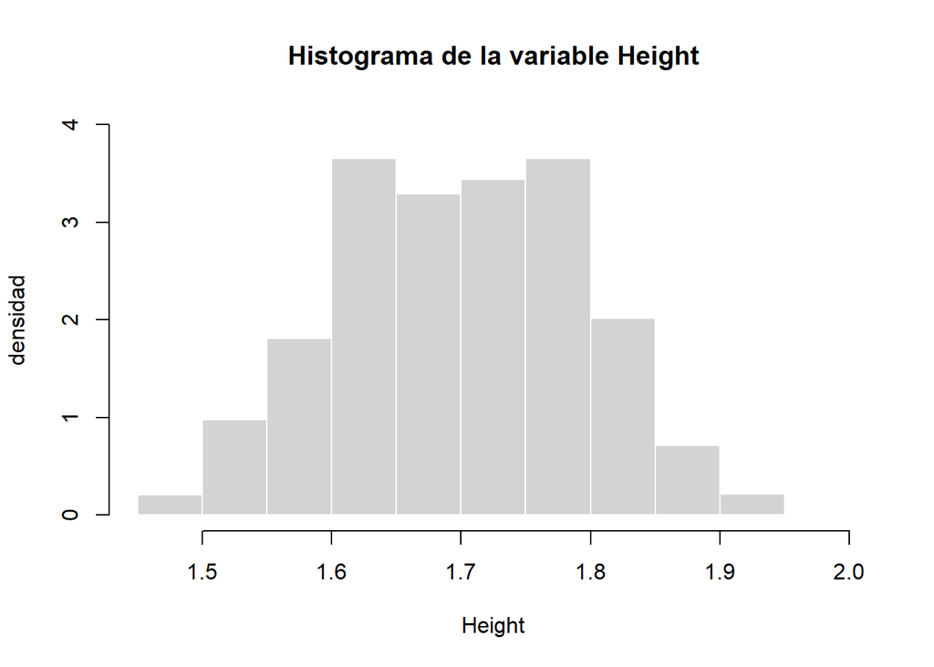

```r
hist(obesity_data_raw$Height, main="Histograma de la variable Height", xlab="Height",ylab="densidad", col="light grey", border = "white", freq = FALSE, ylim = c(0,4))
```

El conjunto de datos cubre alturas entre 1.45 m y 1.98 m, con más observaciónes alrededor del 1.70 m. Todos los valores parecen válidos, aunque hay que observar que no podemos asumir una distribución normal.

```r
shapiro.test(obesity_data_raw$Height)
```

```
##
##  Shapiro-Wilk normality test
##
## data:  obesity_data_raw$Height
## W = 0.99323, p-value = 2.772e-08
```

```r
# p < 0.05 - no podemos asumir la distribción normal.
```

##### **Transformaciones**

Redondeamos los valores de Heigt a 2 decimales.

```r
obesity_data_preprocessed$Height = round(obesity_data_preprocessed$Height, digits = 2)
```

#### **1.4. Weight**

Una variable continua que indica el peso del/de la encuestado/-a, en kilos. Por razónes obvios, se espera que este valor prediga bien el sobrepeso y la obesidad - si sube el peso, suberá también la probabilidad de sobrepeso u obesidad.

```r
table(round(obesity_data_raw$Weight))
```

```
##
##  39  40  41  42  43  44  45  46  47  48  49  50  51  52  53  54  55  56  57  58
##   3   5   5  38   6  10  28   1   4   6  11  75  27  24  16   9  29  26  10  20
##  59  60  61  62  63  64  65  66  67  68  69  70  71  72  73  74  75  76  77  78
##  21  48   9  18  19  20  40  17  16  28  17  51   7  18  10  13  57  18  21  46
##  79  80  81  82  83  84  85  86  87  88  89  90  91  92  93  94  95  96  97  98
##  24  92  21  54  41  22  41  25  24  21  15  43  17   4  10  10  16   9  12  18
##  99 100 101 102 103 104 105 106 107 108 109 110 111 112 113 114 115 116 117 118
##  15  22  12  21  27  14  80  16  11  18  14  22  27  64  23  20  14  10  11  33
## 119 120 121 122 123 124 125 126 127 128 129 130 131 132 133 134 135 136 137 138
##  19  21  44  17   3   3   9   5   4   6  13   8   7  11  20  30   2   2   2  11
## 139 140 141 142 143 144 147 149 150 151 152 153 154 155 156 161 165 173
##   1   1   1   3   2   1   1   1   2   3   7   3   1   2   1   2   1   1
```

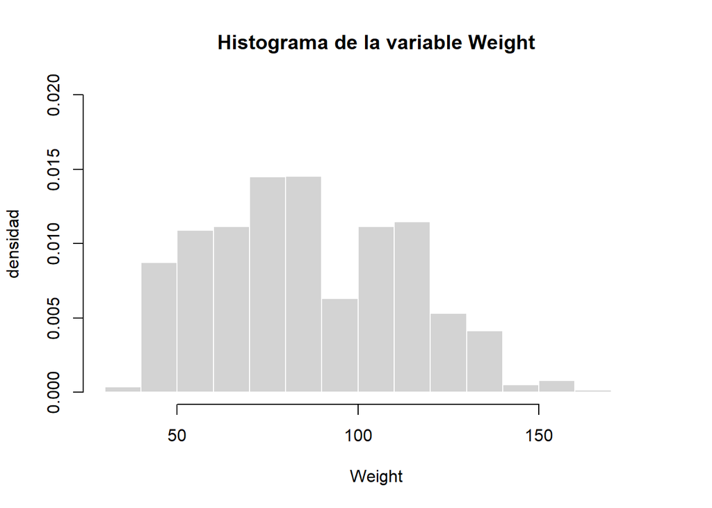

```r
hist(round(obesity_data_raw$Weight), main="Histograma de la variable Weight", xlab="Weight",ylab="densidad", col="light grey", border = "white", freq = FALSE, ylim = c(0,0.02))
```

El conjunto de datos cubre pesos entre 39 kg y 173; todos los valores parecen válidos.

##### Transformaciones

```r
obesity_data_preprocessed$Height = as.integer(round(obesity_data_preprocessed$Height, digits = 2))
```

#### **1.5. BMI**

Es una variable continua que indica el BMI (Body Mass Index - peso/altura^2). No está presente en el conjunto de datos original; calculada a partir de la altura y el peso de cada encuestado/-a incluido en dicho conjunto de datos, de la manera espcificada abajo.

```r
obesity_data_preprocessed$BMI = obesity_data_preprocessed$Weight/obesity_data_preprocessed$Height^2
```

```r
table(round(obesity_data_preprocessed$BMI))
```

```
##
##  39  40  41  42  43  44  45  46  47  48  49  50  51  52  53  54  55  56  57  58
##   3   5   5  38   6  10  28   1   4   6  11  75  27  24  16   9  29  26  10  20
##  59  60  61  62  63  64  65  66  67  68  69  70  71  72  73  74  75  76  77  78
##  21  48   9  18  19  20  40  17  16  28  17  51   7  18  10  13  57  18  21  46
##  79  80  81  82  83  84  85  86  87  88  89  90  91  92  93  94  95  96  97  98
##  24  92  21  54  41  22  41  25  24  21  15  43  17   4  10  10  16   9  12  18
##  99 100 101 102 103 104 105 106 107 108 109 110 111 112 113 114 115 116 117 118
##  15  22  12  21  27  14  80  16  11  18  14  22  27  64  23  20  14  10  11  33
## 119 120 121 122 123 124 125 126 127 128 129 130 131 132 133 134 135 136 137 138
##  19  21  44  17   3   3   9   5   4   6  13   8   7  11  20  30   2   2   2  11
## 139 140 141 142 143 144 147 149 150 151 152 153 154 155 156 161 165 173
##   1   1   1   3   2   1   1   1   2   3   7   3   1   2   1   2   1   1
```

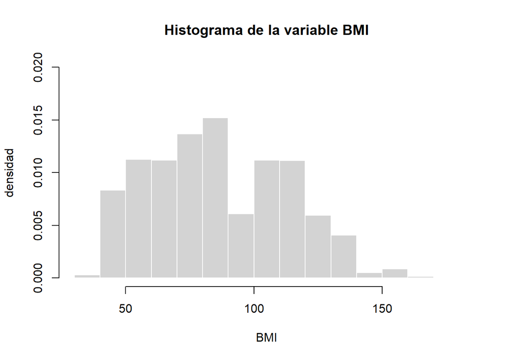

```r
hist(obesity_data_preprocessed$BMI, main="Histograma de la variable BMI", xlab="BMI",ylab="densidad", col="light grey", border = "white", freq = FALSE, ylim = c(0,0.02))
```

El BMI expresa la relación entre la altura y el peso de una persona, indicando así hasta qué punto la persona en cuestión tiene un peso saludable - vease también el apartado ‘7. Weight_Class_WHO’. En otras palabras, debería existir una fuerte relación positiva entre el BMI de un encuestado, y la clase de peso ‘NObeyesdad’ a la que se asigna esa persona (véase el apartado siguiente).

#### **1.6. NObeyesdad / Weight_Class_Mendoza_De_La_Hoz**

Una variable categórica nominal que clasifica los encuestados/-as según grado de peso saludable, como presentado en *Mendoza, Fabio & De la Hoz Manotas, Alexis. (2019). Dataset for estimation of obesity levels based on eating habits and physical condition in individuals from Colombia, Peru and Mexico. Data in Brief. 25. 104344. 10.1016/j.dib.2019.104344*.

Clasifica a los encuestados en una de las siguientes categorías:

Valores disponibles:  
* Insufficient_weight  
* Normal_weight  
* Overweight_level_I  
* Overweight_level_II  
* Obesity_type_I  
* Obesity_type_II  
* Obesity_type_III

Tenga en cuenta que la publicación mencionada no especifica con precisión cómo se asigna una persona determinada a una u otra categoría de peso.

```r
bmi_insufficient_weight = obesity_data_raw$bmi[obesity_data_raw$NObeyesdad =="Insufficient_Weight"]
bmi_normal_weight = obesity_data_raw$bmi[obesity_data_raw$NObeyesdad == "Normal_Weight"]
bmi_overweight_level_I = obesity_data_raw$bmi[obesity_data_raw$NObeyesdad == "Overweight_Level_I"]
bmi_overweight_level_II = obesity_data_raw$bmi[obesity_data_raw$NObeyesdad == "Overweight_Level_II"]
bmi_obesity_type_I = obesity_data_raw$bmi[obesity_data_raw$NObeyesdad == "Obesity_Type_I"]
bmi_obesity_type_II = obesity_data_raw$bmi[obesity_data_raw$NObeyesdad == "Obesity_Type_II"]
bmi_obesity_type_III = obesity_data_raw$bmi[obesity_data_raw$NObeyesdad == "Obesity_Type_III"]

summary(bmi_insufficient_weight)
```

```
## Length  Class   Mode
##      0   NULL   NULL
```

```r
summary(bmi_normal_weight)
```

```
## Length  Class   Mode
##      0   NULL   NULL
```

```r
summary(bmi_overweight_level_I)
```

```
## Length  Class   Mode
##      0   NULL   NULL
```

```r
summary(bmi_overweight_level_II)
```

```
## Length  Class   Mode
##      0   NULL   NULL
```

```r
summary(bmi_obesity_type_I)
```

```
## Length  Class   Mode
##      0   NULL   NULL
```

```r
summary(bmi_obesity_type_II)
```

```
## Length  Class   Mode
##      0   NULL   NULL
```

```r
summary(bmi_obesity_type_III)
```

```
## Length  Class   Mode
##      0   NULL   NULL
```

```r
rm(bmi_insufficient_weight)
rm(bmi_normal_weight)
rm(bmi_overweight_level_I)
rm(bmi_overweight_level_II)
rm(bmi_obesity_type_I)
rm(bmi_obesity_type_II)
rm(bmi_obesity_type_III)
```

```r
table(obesity_data_raw$NObeyesdad)
```

```
##
## Insufficient_Weight       Normal_Weight      Obesity_Type_I     Obesity_Type_II
##                 272                 287                 351                 297
##    Obesity_Type_III  Overweight_Level_I Overweight_Level_II
##                 324                 290                 290
```

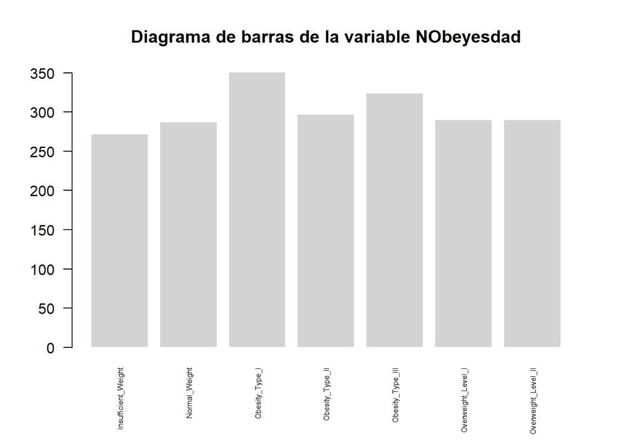

```r
barplot(table(obesity_data_raw$NObeyesdad), main="Diagrama de barras de la variable NObeyesdad", col="light grey", border = "white", las=2, cex.names = 0.5)
```

#### **Transformaciones**  
Aplicamos ‘label encoding’, es decir, sustituiremos los valores que consisten de texto por valores numéricos, de acuerdo con la siguente asignación.

- 0 - Insufficient_weight
- 1 - Normal_weight
- 2 - Overweight_level_I
- 3 - Overweight_level_II
- 4 - Obesity_type_I
- 5 - Obesity_type_II
- 6 - Obesity_type_III

Además, cambiamos el nombre de la variable - para que refleje mejor la carga de la variable, para que tenga una capitalización en linéa con las otras variables, y para que sea más distingida de la otra variable que compone una categorización de peso (Weight_CLass_WHO, veáse a continuación).

#### **1.7 Weight_Class_WHO**

Es variable discreta ordinal que clasifica los encuestados/-as según grado de peso saludable, según la normativa de la Organización Mundial de la Salud (OMS, WHO en inglés).

Es un dato no presente en el conjunto de datos original, calculada a partir del BMI de cada encuestado/-a de acuerdo con la siguiente asignación:

- 0 - Infrapeso (BMI bajo 18.5)
- 1 - Normal (BMI entre 18.5 y 24.9)
- 2 - Sobrepeso (BMI entre 25.0 y 29.9)
- 3 - Obesidad I (BMI entre 30.0 y 34.9)
- 4 - Obesidad II (BMI entry 35.0 y 39.9)
- 5 - Obesidad III (BMI superior a 40)

```r
obesity_data_preprocessed$Weight_Class_WHO = as.integer(
    ifelse(
    obesity_data_preprocessed$Weight/obesity_data_preprocessed$Height^2 > 40, 5, ifelse(
      obesity_data_preprocessed$Weight/obesity_data_preprocessed$Height^2 >= 35, 4, ifelse(
        obesity_data_preprocessed$Weight/obesity_data_preprocessed$Height^2 >= 30, 3, ifelse(
          obesity_data_preprocessed$Weight/obesity_data_preprocessed$Height^2 >= 25, 2, ifelse(
            obesity_data_preprocessed$Weight/obesity_data_preprocessed$Height^2 >= 18.5, 1, 0
          )
        )
      )
    )
  )
)
```

```r
table(obesity_data_preprocessed$Weight_Class_WHO)
```

```
##
##    4    5
##    6 2105
```

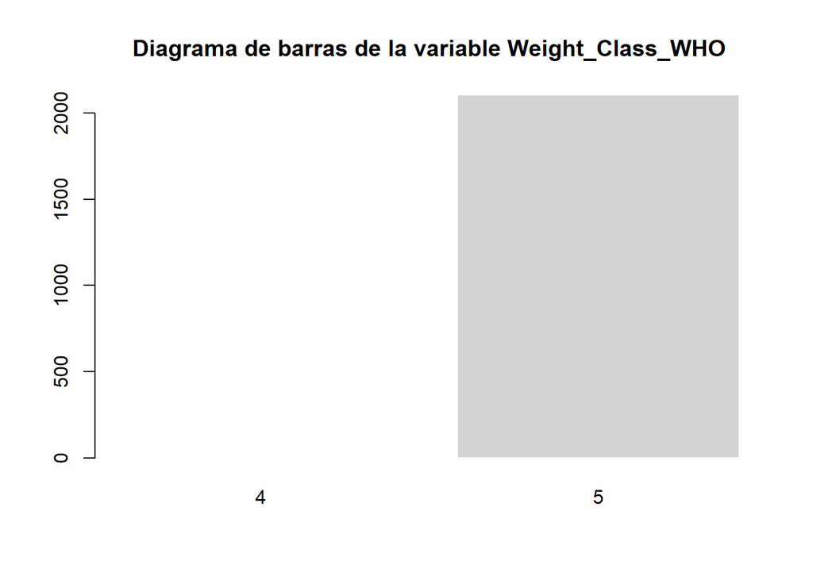

```r
barplot(table(obesity_data_preprocessed$Weight_Class_WHO), main="Diagrama de barras de la variable Weight_Class_WHO", col="light grey", border = "white")
```

#### **1.8. family_history_with_overweight / Overweight_Family**

Es una variable binaria que indica si tiene familiares con sobrepeso el/la encuestado/-a.

Podía ser una variable miu potente en predicir la probabilidad de sobrepeso en una persona; sin embargo, un interrogatorio más específico podría haber dado lugar a un predictor más potente - por ejemplo, si alguien tiene padres o hermanos con sobrepeso. ‘Familia’ es un un concepto muy amplio, y sin marcas claras - algo que se ve reflejado en el hecho que una gran mayoría de los encuestados (casí 82 %) sí tiene algún miembro de familia con sobrepeso.

```r
table(obesity_data_raw$family_history_with_overweight)
```

```
##
##   no  yes
##  385 1726
```

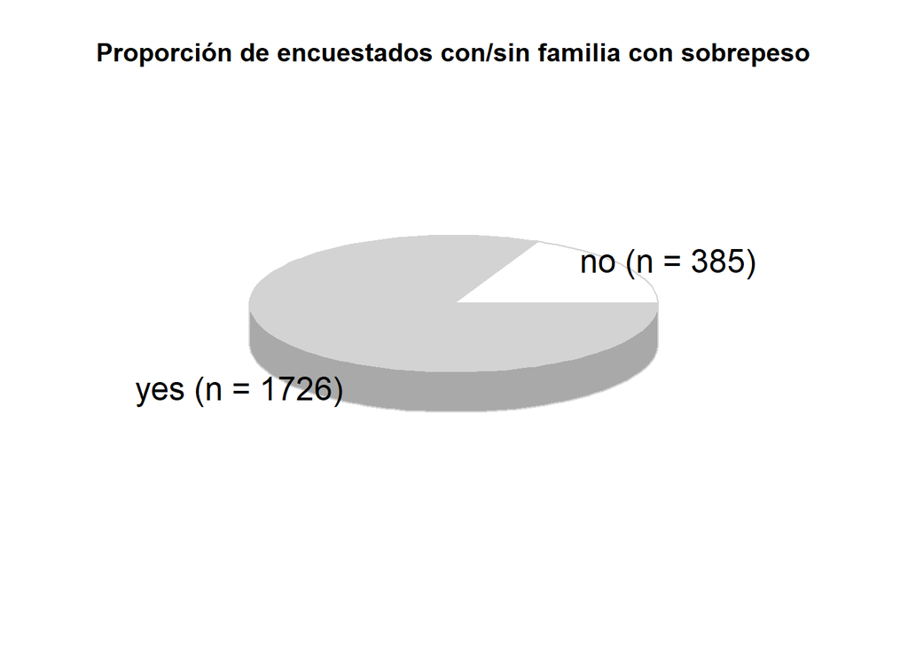

```r
pie3D(table(as.factor(obesity_data_raw$family_history_with_overweight)), main = "Proporción de encuestados con/sin familia con sobrepeso", col = c("white", "light grey"), border = "light grey", labels = c("no (n = 385)", "yes (n = 1726)"))
```

#### **Transformaciones**

Aplicamos ‘label encoding’, es decir, sustituiremos los valores que consisten de texto por valores numéricos, de acuerdo con la siguente asignación.

- 0 - no
- 1 - yes

Además, cambiamos el nombre de la variable - para que que tenga una capitalización en conformidad con las otras variables; en el proceso, también hacemos el nombre un poco más corto. La nombramos ‘Overweight_Family’.

```r
obesity_data_preprocessed$Overweight_Family = as.integer(ifelse(obesity_data_preprocessed$family_history_with_overweight == "no", 0, 1))
```

#### **1.9 FAVC / High_Caloric_Consumption**

Se trata de variable binaria que indica si el/la encuestado/-a consume comida rica en calorías regularmente.

```r
table(as.factor(obesity_data_raw$FAVC))
```

```
##
##   no  yes
##  245 1866
```

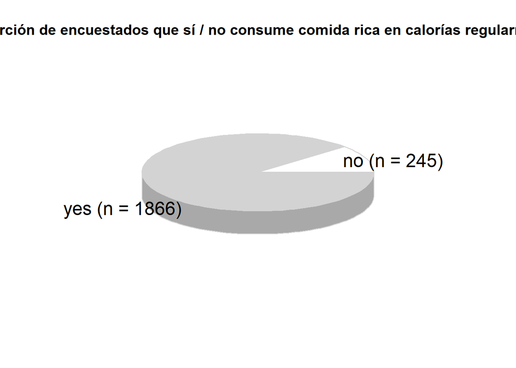

```r
pie3D(table(as.factor(obesity_data_raw$FAVC)), main = "Proporción de encuestados que sí / no consume comida rica en calorías regularmente", col = c("white", "light grey"), border = "light grey", labels = c("no (n = 245)", "yes (n = 1866)"))
```

Hacemos la misma observación que en relación con la variable anterior: podía ser muy potente para predicir el sobrepeso - obviamente - pero la formulación poca definida de la pregunta probablemente ha quitado algo de esa potencia. Más especifífico: qué quiere decir ‘regularmente’?

Efectivamente, vemos que de nuevo una gran mayoría de los encuestados (más que 88%) ha respondido de manera confirmativa.

#### **Transformacione**s

Aplicamos ‘label encoding’, es decir, sustituiremos los valores que consisten de texto por valores numéricos, de acuerdo con la siguente asignación.

- 0 - no
- 1 - yes

Además, cambiamos el nombre de la variable - para que que tenga una capitalización en conformidad con las otras variables, y para evitar abreviacióne potencialmente confusas. La nombramos ‘High_Caloric_Consumption’.

```r
obesity_data_preprocessed$High_Caloric_Consumption = as.integer(ifelse(obesity_data_preprocessed$FAVC == "no", 0, 1))
```

#### **1.10 FCVC / Vegetable_Consumption**

Se trata variable categórica ordinal que indica como de frequente el/la encuestado/-a consume verduras, según la siguiente asignación.

- 1 - Nunca
- 2 - De vez en cuando
- 3 - Siempre

```r
table(round(obesity_data_raw$FCVC))
```

```
##
##    1    2    3
##  102 1013  996
```

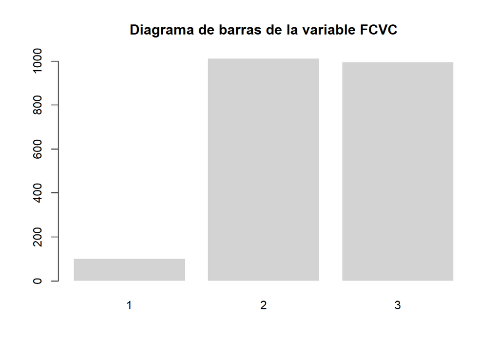

```r
barplot(table(round(obesity_data_raw$FCVC)), main="Diagrama de barras de la variable FCVC", col="light grey", border = "white")
```

Podía ser un buen predictor para el sobrepeso de una persona, especialmente combinado con otras variables que indican una dieta sana (por ejemplo, la consomación de agua, no consumir entre comidas principales).

#### **Transformaciones**

En el conjunto de datos original, la variable FCVC tome valores descimales, algo aue no es conforme con el hecho que es una variable discreta. Por eso, vamos a redondearla. Después, para guardar la conformidad en el conjunto de datos, la transformamos de forma que el valor más bajo sea 0. La asinación nueva será, entonces:

- 0 - Nunca
- 1 - De vez en cuando
- 2 - Siempre

Además le nombramos ‘Vegetable_Consumption’, para evitar abreviaciónes potencialmente confusas.

```r
obesity_data_preprocessed$Vegetable_Consumption = as.integer(
  round(
    ifelse(
      obesity_data_preprocessed$FCVC == 1, 0, ifelse(
      obesity_data_preprocessed$FCVC == 2, 1, 2
      )
    )
  )
)
```

#### **1.11. NCP / Main_Meals**

Se trata de una variable categorica ordinal que indica cuantas comidas principales come el/la encuestado/-a por día.

La descripción del conjunto de datos indica, que el encuesto ofreció las siguientes respuestas a la pregunta, cuántas comidas principales el/la encuestado/-a consumepor día.

- 1 o 2
- 3
- Más que 3

Sin embargo, cuando miramos los valores presentes en el conjunto de datos, encontramos valores hasta 4. Además, el hecho que el valor más frequente es ‘3’ sugiere que, en realidad, esa variable indica la cantidad de comidas principales por día (desayuno - almuerzo - cena).

```r
table(round(obesity_data_raw$NCP))
```

```
##
##    1    2    3    4
##  316  176 1470  149
```

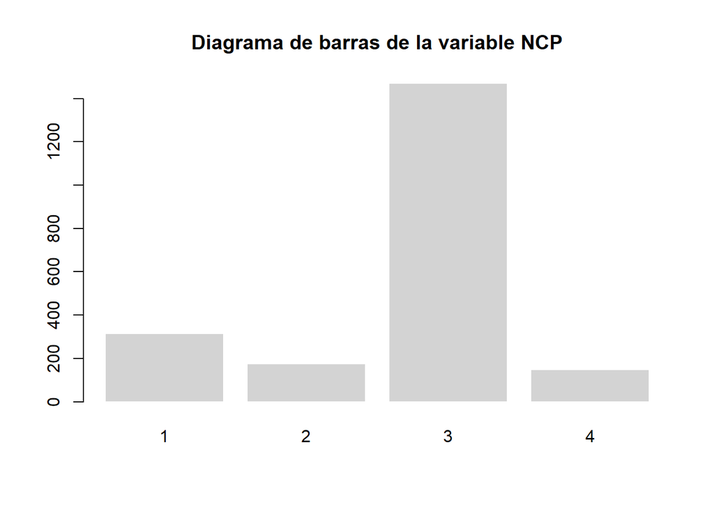

```r
barplot(table(round(obesity_data_raw$NCP)), main="Diagrama de barras de la variable NCP", col="light grey", border = "white")
```

No esperamos una relación fuerte entre cantidad de comidas principales, y el sobrepeso. Quizá exista una relación indirecta: las personas con patrones alimentarios menos estructurados -es decir, las que hacen menos comidas principales- pueden picar más, lo que aumentaría el riesgo de obesidad.

#### **Transformaciones**

Visto que se trata de una variable discreta, redondeamos sus valores. Adeḿas cambiamos su nombre a ‘Main_Meals’, para evitar abreviaciónes potencialmente confusas.

```r
obesity_data_preprocessed$Main_Meals = as.integer(round(obesity_data_preprocessed$NCP))
```

#### **1.12. CAEC / Between_Meals**

Es una variable categorica ordinal que indica como de frequente el/la encuestado/-a come entre comidas principales.

```r
table(factor(obesity_data_raw$CAEC, levels = c("no", "Sometimes", "Frequently", "Always")))
```

```
##
##         no  Sometimes Frequently     Always
##         51       1765        242         53
```

```r
table(factor(obesity_data_raw$CAEC, levels = c("no", "Sometimes", "Frequently", "Always")))
```

```
##
##         no  Sometimes Frequently     Always
##         51       1765        242         53
```

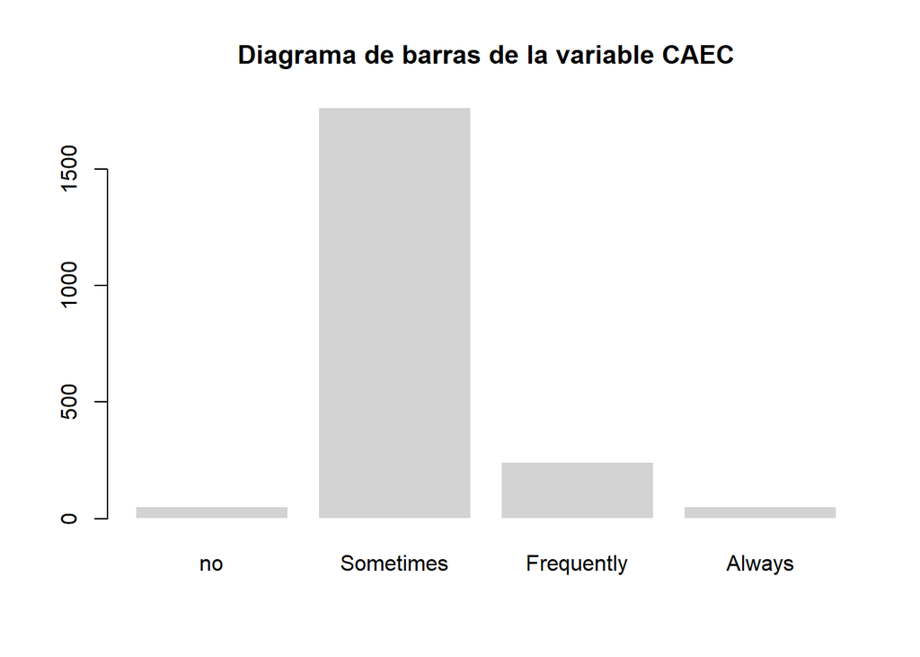

```r
barplot(table(factor(obesity_data_raw$CAEC, levels = c("no", "Sometimes", "Frequently", "Always"))), main="Diagrama de barras de la variable CAEC", col="light grey", border = "white")
```

la frecuencia con la que una persona come entre las comidas principales podría ser un buen indicador del sobrepeso. Sin embargo, la subjetivdad de las respuestas presentadas a los encuestados quita algo de esa potencia - la gran mayoría (más que 83%) tiene la percepción de comer entre comidas principales ‘de vez en cuando’ - pero no se especifica qué significa exactamente “de vez en cuando”. Tampóco no da ningúna indicación de qué cantidad de comida se trata.

#### **Transformaciones**

Aplicamos ‘label encoding’, es decir, sustituiremos los valores que consisten de texto por valores numéricos, de acuerdo con la siguente asignación.

- 0 - No
- 1 - De vez en cuando
- 2 - Frequentemente
- 3 - Siempre

Además, cambiamos el nombre de la variable - para que que tenga una capitalización en conformidad con las otras variables, y para evitar abreviacióne potencialmente confusas. La nombramos ‘Between_Meals’.

```r
obesity_data_preprocessed$Between_Meals = as.integer(
  ifelse(
    obesity_data_preprocessed$CAEC == "no", 0, ifelse(
      obesity_data_preprocessed$CAEC == "Sometimes", 1, ifelse(
        obesity_data_preprocessed$CAEC == "Frequently", 2, 3
      )
    )
  )
)
```